# Wine Quality Exploration

Miadad Rashid

Tuesday, May 05, 2015

Table of Contents

1. Introduction
2. Exploration
   1. General Statistics
   2. Quality Distributions
   3. Related Variables (Intuitively)
   4. Other Related Variables (Unintuitively)
3. Conclusion

# 1. Introduction

In the following we will be exploring 2 datasets. Both data sets document the quality of wine and their associated physiochemical properties. The data sets are divided into red and white wines. The grape is the Portugese varietal of *Vinho Verde*. Documentation of the entire study can be found [here](http://www.sciencedirect.com/science/article/pii/S0167923609001377). Documentation of the data set and its subsequent variables can be found [here](https://s3.amazonaws.com/udacity-hosted-downloads/ud651/wineQualityInfo.txt). For the purposes of determining patterns in the overall designation of wine, I combined the 2 datasets and added a categorical variable called `type` which denotes whether the particular iteration is `white` or `red` wines. This should not impede any analysis of the individual `type` of wine but should streamline the analysis of the relationship of quality to the physiochemical properties of the wine varietal in whole.

# 1. Exploration

### 1.1 General Statistics

*Note: After the loading of the datasets, an additional variable, `type`, was added to indicate the type of wine; `Red Wine` for red wine and `White Wine` for white wine. This was to help identify the type of wine when both datasets were combined.*

- Red Wine Dimensions

```
## [1] 1599   13
```

- White Wine Dimensions

```
## [1] 4898   13
```

**Note: There are considerably more white wine iterations than there are red wine iterations. This may or may not make a difference when analyzing the 2 datasets as one. I have created 2 different combinations, 1 data set is a straight combination of the 2 data sets, the other is a combination of the red wine data set AND the white wine data set of which I randomly chose observations from so the number of observations were equal to the red wine data set. We will be conducting analysis on both so the type of dataset will be denoted in the title as `Equalized` or `Unequal`.**

- Variables (both datasets have identical covariates)

```
##  [1] "fixed.acidity"        "volatile.acidity"     "citric.acid"
##  [4] "residual.sugar"       "chlorides"            "free.sulfur.dioxide"
##  [7] "total.sulfur.dioxide" "density"              "pH"
## [10] "sulphates"            "alcohol"              "quality"
## [13] "type"
```

*Note: the `X` variable is an index variable and will be removed as it will interfere with the combination of the 2 datasets and is incidentally uneeded.*

- Summarizations for Red Wines

```
##  fixed.acidity   volatile.acidity  citric.acid    residual.sugar
##  Min.   : 4.60   Min.   :0.1200   Min.   :0.000   Min.   : 0.900
##  1st Qu.: 7.10   1st Qu.:0.3900   1st Qu.:0.090   1st Qu.: 1.900
##  Median : 7.90   Median :0.5200   Median :0.260   Median : 2.200
##  Mean   : 8.32   Mean   :0.5278   Mean   :0.271   Mean   : 2.539
##  3rd Qu.: 9.20   3rd Qu.:0.6400   3rd Qu.:0.420   3rd Qu.: 2.600
##  Max.   :15.90   Max.   :1.5800   Max.   :1.000   Max.   :15.500
##    chlorides       free.sulfur.dioxide total.sulfur.dioxide
##  Min.   :0.01200   Min.   : 1.00       Min.   :  6.00
##  1st Qu.:0.07000   1st Qu.: 7.00       1st Qu.: 22.00
##  Median :0.07900   Median :14.00       Median : 38.00
##  Mean   :0.08747   Mean   :15.87       Mean   : 46.47
##  3rd Qu.:0.09000   3rd Qu.:21.00       3rd Qu.: 62.00
##  Max.   :0.61100   Max.   :72.00       Max.   :289.00
##     density             pH          sulphates         alcohol
##  Min.   :0.9901   Min.   :2.740   Min.   :0.3300   Min.   : 8.40
##  1st Qu.:0.9956   1st Qu.:3.210   1st Qu.:0.5500   1st Qu.: 9.50
##  Median :0.9968   Median :3.310   Median :0.6200   Median :10.20
##  Mean   :0.9967   Mean   :3.311   Mean   :0.6581   Mean   :10.42
##  3rd Qu.:0.9978   3rd Qu.:3.400   3rd Qu.:0.7300   3rd Qu.:11.10
##  Max.   :1.0037   Max.   :4.010   Max.   :2.0000   Max.   :14.90
##     quality          type
##  Min.   :3.000   Length:1599
##  1st Qu.:5.000   Class :character
##  Median :6.000   Mode  :character
##  Mean   :5.636
##  3rd Qu.:6.000
##  Max.   :8.000
```

- Summarizations for White Wines

```
##  fixed.acidity    volatile.acidity  citric.acid     residual.sugar
##  Min.   : 3.800   Min.   :0.0800   Min.   :0.0000   Min.   : 0.600
##  1st Qu.: 6.300   1st Qu.:0.2100   1st Qu.:0.2700   1st Qu.: 1.700
##  Median : 6.800   Median :0.2600   Median :0.3200   Median : 5.200
##  Mean   : 6.855   Mean   :0.2782   Mean   :0.3342   Mean   : 6.391
##  3rd Qu.: 7.300   3rd Qu.:0.3200   3rd Qu.:0.3900   3rd Qu.: 9.900
##  Max.   :14.200   Max.   :1.1000   Max.   :1.6600   Max.   :65.800
##    chlorides       free.sulfur.dioxide total.sulfur.dioxide
##  Min.   :0.00900   Min.   :  2.00      Min.   :  9.0
##  1st Qu.:0.03600   1st Qu.: 23.00      1st Qu.:108.0
##  Median :0.04300   Median : 34.00      Median :134.0
##  Mean   :0.04577   Mean   : 35.31      Mean   :138.4
##  3rd Qu.:0.05000   3rd Qu.: 46.00      3rd Qu.:167.0
##  Max.   :0.34600   Max.   :289.00      Max.   :440.0
##     density             pH          sulphates         alcohol
##  Min.   :0.9871   Min.   :2.720   Min.   :0.2200   Min.   : 8.00
##  1st Qu.:0.9917   1st Qu.:3.090   1st Qu.:0.4100   1st Qu.: 9.50
##  Median :0.9937   Median :3.180   Median :0.4700   Median :10.40
##  Mean   :0.9940   Mean   :3.188   Mean   :0.4898   Mean   :10.51
##  3rd Qu.:0.9961   3rd Qu.:3.280   3rd Qu.:0.5500   3rd Qu.:11.40
##  Max.   :1.0390   Max.   :3.820   Max.   :1.0800   Max.   :14.20
##     quality          type
##  Min.   :3.000   Length:4898
##  1st Qu.:5.000   Class :character
##  Median :6.000   Mode  :character
##  Mean   :5.878
##  3rd Qu.:6.000
##  Max.   :9.000
```

**When looking at the distributions of the physiochemical properties, you can notice some major outliers on some of the covariates. Namely, `residual.sugar`, `chlorides`, `sulphates`, and `total.sulfur.dioxide`. These variables’ `max` values are considerably higher than the other parameters while the `mean` and `median` stay within a relatively small range. If we were to consider this dataset for predictive modeling, it may be beneficial to remove these outliers. Removing these observations could also increase correlative values between the covariates as well as the `quality` variable.**

###1.2 Quality Distributions between Red and White Wines

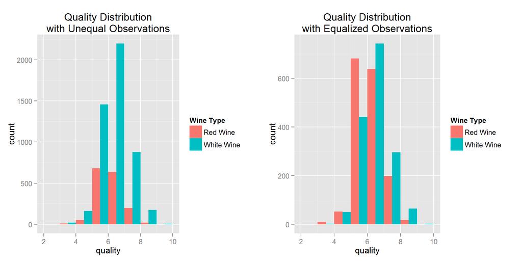

- Table of Quality (Unequal Observations)

```
## [1] "Red Wines"
```

```
##
##   3   4   5   6   7   8
##  10  53 681 638 199  18
```

```
## [1] "White Wines"
```

```
##
##    3    4    5    6    7    8    9
##   20  163 1457 2198  880  175    5
```

- Table of Quality (Equalized Observations)

```
## [1] "Red Wines"
```

```
##
##   3   4   5   6   7   8
##  10  53 681 638 199  18
```

```
## [1] "White Wines"
```

```
##
##   3   4   5   6   7   8   9
##   2  50 441 743 296  65   2
```

**Note: The distributions of the outcome variable, `quality`, seem to be normal.**

### 1.3 Related Variables (Intuitive Relation)

These variables have known relations to one another and *should* be reflected in the data such as the relation of `pH` to any of the acid variables in the data. The correlative values should also be significant.

- Total Acidity to pH

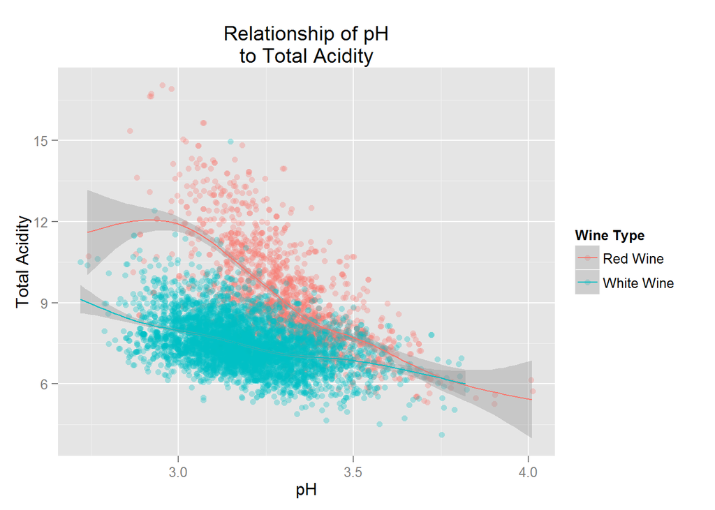

For this particular graph I added all the acid indicating components, `fixed.acidity` + `volatile.acidity` + `citric.acid`, as `Total Acidity` and compared it to the `pH` variable. If the data is sound, `pH` should have an inverse relationship to `Total Acidity`, and it does.

Another interesting observation is that the rate of change seem to be much less for white wines than it is for red wines. Considering there is considerably more data for white wines than there is red wines, this simply be a result be a result of lack of red wine observations. We can deal with this by sampling random iterations of the `White Wines` equal to the iterations of `Red Wines`.’

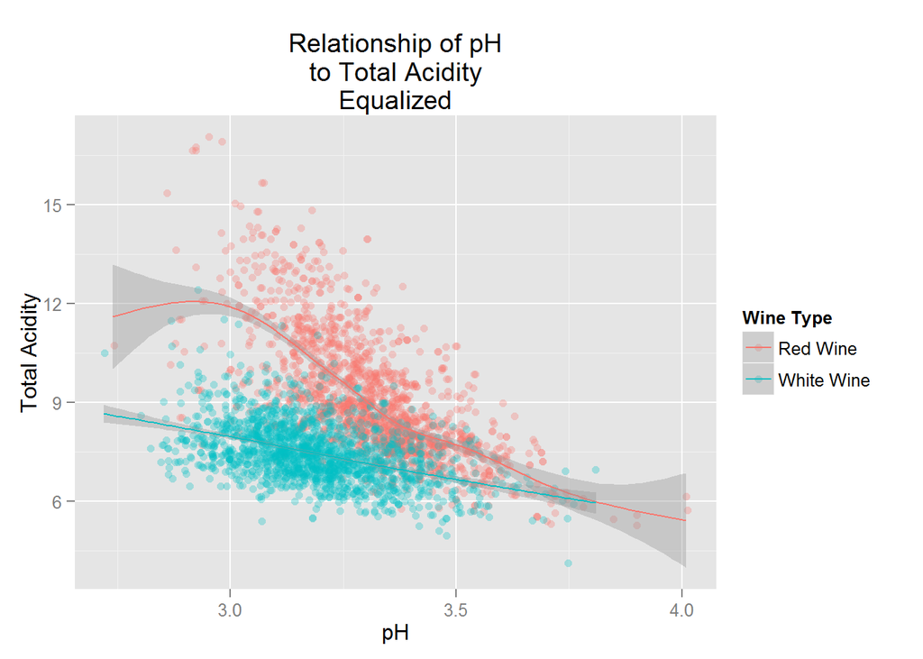

Although the areas of red wine vs white wine seems to be more distinct, the red wine rate of change is still more rapid than white wine.

- Alcohol and Density

Alcohol has less density compared to other consumable liquids, specifically water. While water has a density of 1 gram per cubic centimeter, alcohol has a density of about 0.79 g/cc, at equal pressure and temperature. The more alcohol vs other liquids a wine contains should decrease the overall density of the wine. So a comparison between alcohol level and density should show an inverse relationship.

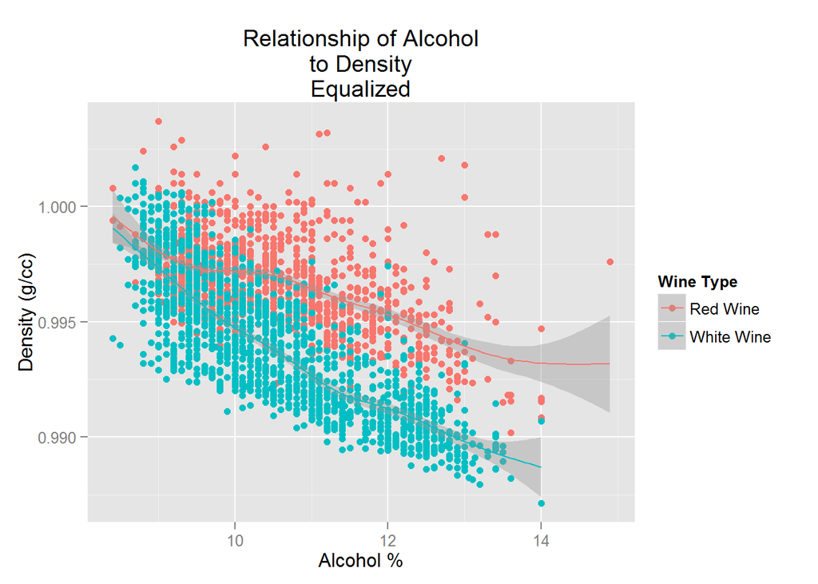

### 1.4 Related Variables (Unintuitive Relation)

In the previous area, we looked at variables that *should* have correlation, whether negative or positive. There maybe other variables that have such correlations we may not have intuitively examined.

- Correlation of Variables on the Equalized Data Set

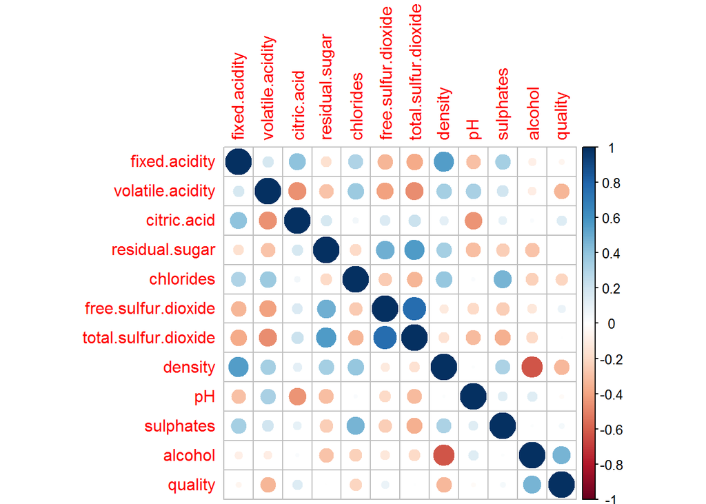

As covered in the previous section, there is a strong correlation between `alcohol` and `density`. But there were, indeed, some correlated variables that have interesting relationships to one another.

- `pH` to `volatile.acidity`

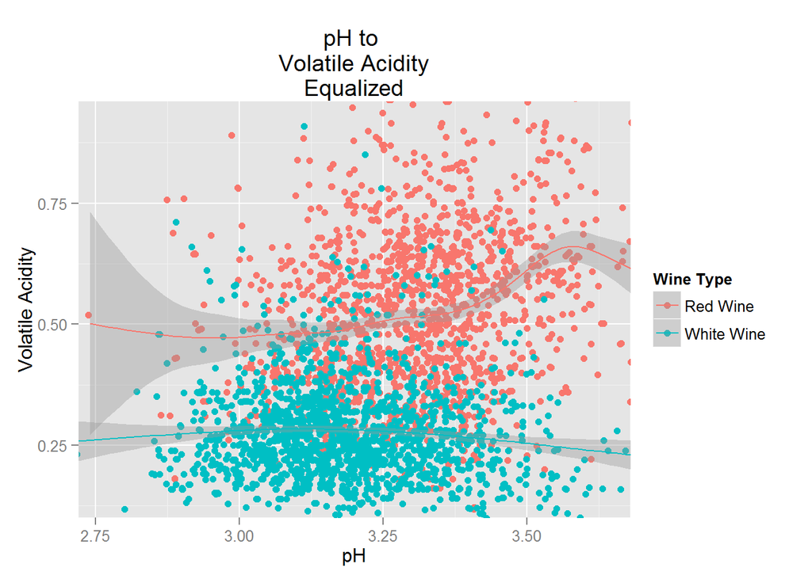

Although the `pH` to `fixed.acidity` and `citric.acid` seem to have a negative correlation, as expected, `ph` seems to also have a positive correlation with `volatile.acidity`. This was unexpected since acidic compounds encompass the lower numbers in the `ph` scale. Doing further research, I have found that `volatile.acidity` in the documentation is also known as acetic acid. Acetic acid is considered a weak acid, and one of two weak acids. Weak acids are categorized as such because they simultaneously contain their conjugate base, higher pH, and acidic parts in one solution. More information can be found [here](http://en.wikipedia.org/wiki/Acid_strength). This could possibly explain the positive correlation between `pH` and `volatile.acidity`.

- `density` to `fixed.acidity`

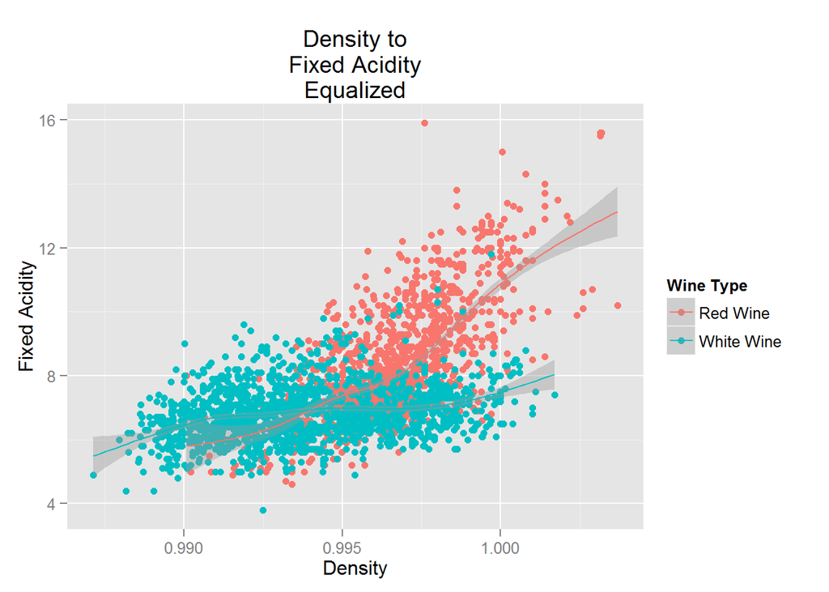

Another high correlation is between `density` and `fixed.acidity`. The three prime acids found in wine are **tartaric acid**, **malic acid**, and **citric acid**. When looking at the densities of these acids we find that…

- tartaric acid : 1.79 g/cm^3
- malic acid : 1.61 g/cm^3
- citric acid : 1.67 g/cm^3

All of these acids have a higher density than water, which has a density of 1.0 g/cm^3. We are left to conclude that the higher the acid concentration in a given compound relative to water, the more dense it becomes, with all else being equal.

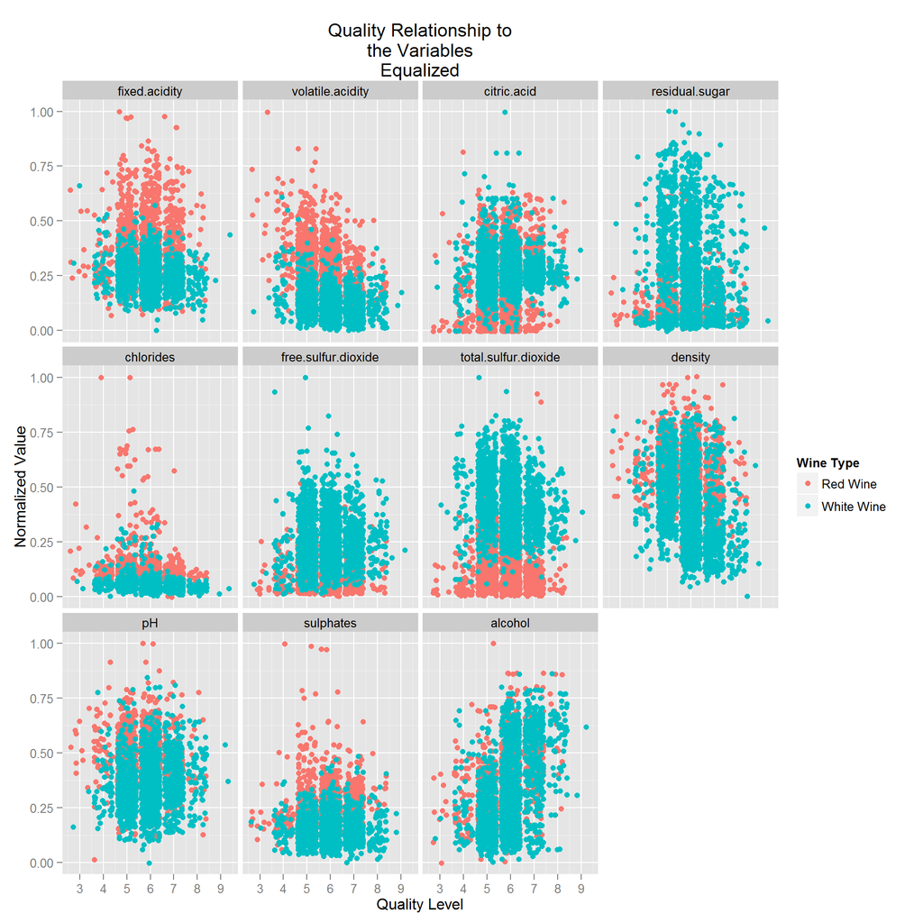